# Chopsticks!

A few researchers set out to determine the optimal length of chopsticks for children and adults. They came up with a measure of how effective a pair of chopsticks performed, called the "Food Pinching Performance." The "Food Pinching Performance" was determined by counting the number of peanuts picked and placed in a cup (PPPC).

### An investigation for determining the optimum length of chopsticks.

[Link to Abstract and Paper](http://www.ncbi.nlm.nih.gov/pubmed/15676839)  
*the abstract below was adapted from the link*

Chopsticks are one of the most simple and popular hand tools ever invented by humans, but have not previously been investigated by ergonomists. Two laboratory studies were conducted in this research, using a [randomised complete block design](http://dawg.utk.edu/glossary/whatis_rcbd.htm), to evaluate the effects of the length of the chopsticks on the food-serving performance of adults and children. Thirty-one male junior college students and 21 primary school pupils served as subjects for the experiment to test chopsticks lengths of 180, 210, 240, 270, 300, and 330 mm. The results showed that the food-pinching performance was significantly affected by the length of the chopsticks, and that chopsticks of about 240 and 180 mm long were optimal for adults and pupils, respectively. Based on these findings, the researchers suggested that families with children should provide both 240 and 180 mm long chopsticks. In addition, restaurants could provide 210 mm long chopsticks, considering the trade-offs between ergonomics and cost.

### For the rest of this project, answer all questions based only on the part of the experiment analyzing the thirty-one adult male college students.

Download the [data set for the adults](https://www.udacity.com/api/nodes/4576183932/supplemental_media/chopstick-effectivenesscsv/download), then answer the following questions based on the abstract and the data set.

**If you double click on this cell**, you will see the text change so that all of the formatting is removed. This allows you to edit this block of text. This block of text is written using [Markdown](http://daringfireball.net/projects/markdown/syntax), which is a way to format text using headers, links, italics, and many other options. You will learn more about Markdown later in the Nanodegree Program. Hit shift + enter or shift + return to show the formatted text.

#### 1. What is the independent variable in the experiment?

You can either double click on this cell to add your answer in this cell, or use the plus sign in the toolbar (Insert cell below) to add your answer in a new cell.

Chopstick.Length

#### 2. What is the dependent variable in the experiment?

Food.Pinching.Efficiency

#### 3. How is the dependent variable operationally defined?

peanuts picked and placed in a cup (PPPC)

#### 4. Based on the description of the experiment and the data set, list at least two variables that you know were controlled.

Think about the participants who generated the data and what they have in common. You don't need to guess any variables or read the full paper to determine these variables. (For example, it seems plausible that the material of the chopsticks was held constant, but this is not stated in the abstract or data description. Because of this, chopstick material should not be cited as a controlled variable.)

Level of education: Junior college and school pupil  
Gender: Male  
Chopstick : Different lengths ranging from 180mm - 330mm Distribution of these 2 groups into treatment and control blocks

One great advantage of ipython notebooks is that you can document your data analysis using code, add comments to the code, or even add blocks of text using Markdown. These notebooks allow you to collaborate with others and share your work. For now, let's see some code for doing statistics.

```python
import pandas as pd
import os
import numpy as np

# pandas is a software library for data manipulation and analysis
# We commonly use shorter nicknames for certain packages. Pandas is often abbreviated to pd.
# hit shift + enter to run this cell or block of code
```

```python
path = r'W:\Udacity\DAND'
filename = 'chopstick-effectiveness.csv'
# Change the path to the location where the chopstick-effectiveness.csv file is located on your computer.
# If you get an error when running this block of code, be sure the chopstick-effectiveness.csv is located at the path on your computer.

dataFrame = pd.read_csv(os.path.join(path, filename))
dataFrame.groupby('Chopstick.Length').count()
```

| Chopstick.Length | Food.Pinching.Efficiency | Individual |
| --- | --- | --- |
| 180 | 31 | 31 |
| 210 | 31 | 31 |
| 240 | 31 | 31 |
| 270 | 31 | 31 |
| 300 | 31 | 31 |
| 330 | 31 | 31 |

```python
dataFrame['Food.Pinching.Efficiency'].mean()
print 'Correlation between chopstick length and food pinching efficiency', np.corrcoef(dataFrame['Chopstick.Length'], dataFrame['Food.Pinching.Efficiency'])[0, 1]
```

```
Correlation between chopstick length and food pinching efficiency -0.0996033390762
```

This number is helpful, but the number doesn't let us know which of the chopstick lengths performed best for the thirty-one male junior college students. Let's break down the data by chopstick length. The next block of code will generate the average "Food Pinching Effeciency" for each chopstick length. Run the block of code below.

```python
meansByChopstickLength = dataFrame.groupby('Chopstick.Length')['Food.Pinching.Efficiency'].mean().reset_index()
meansByChopstickLength

# reset_index() changes Chopstick.Length from an index to column. Instead of the index being the length of the chopsticks, the index is the row numbers 0, 1, 2, 3, 4, 5.
```

|  | Chopstick.Length | Food.Pinching.Efficiency |
| --- | --- | --- |
| 0 | 180 | 24.935161 |
| 1 | 210 | 25.483871 |
| 2 | 240 | 26.322903 |
| 3 | 270 | 24.323871 |
| 4 | 300 | 24.968065 |
| 5 | 330 | 23.999677 |

#### 5. Which chopstick length performed the best for the group of thirty-one male junior college students?

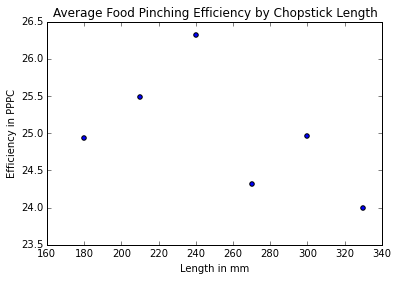

```python
# Causes plots to display within the notebook rather than in a new window
%pylab inline

import matplotlib.pyplot as plt

plt.scatter(x=meansByChopstickLength['Chopstick.Length'], y=meansByChopstickLength['Food.Pinching.Efficiency'])
            # title="")
plt.xlabel("Length in mm")
plt.ylabel("Efficiency in PPPC")
plt.title("Average Food Pinching Efficiency by Chopstick Length")
plt.show()
```

Chopstick length of 240mm performed the best

#### 6. Based on the scatterplot created from the code above, interpret the relationship you see. What do you notice?

While there are too few datapoints to make any meaningful interpretation. Overall, the data show a weak negative correlation. However, between 180mm - 240mm, the efficiency linearly increases, and above 240mm, there is a sudden non-linear drop in efficiency relative to the band between 180mm - 240mm

### In the abstract the researchers stated that their results showed food-pinching performance was significantly affected by the length of the chopsticks, and that chopsticks of about 240 mm long were optimal for adults.

#### 7a. Based on the data you have analyzed, do you agree with the claim?

#### 7b. Why?

The data reveal that efficiency peaks at 26.322903 ppuc for 240mm chopstick length, and then drops to 24.323871 ppuc at 270mm; it briefly rises before falling further to 23.999677 at 330mm.  
Yes. Because this was a randomized controlled experiment; the 2 groups (Junior college and school pupils) were uniformly assigned to the treatment and control group, and the researchers used various treatments (different chopstick legnth) on them to measure food pinching efficiency. However, these results may work only on one type of activity with the chopstick: food pinching; this doesn't tell us how performance is impacted when performing food pulling, or tearing tasks.